# Lab 2 - Gr. 14 - Bioinformatics (732A93)

Julius Kittler (julki092), Stefano Toffol (steto820), Saewon Jun (saeju204), Maximilian Pfundstein (maxpf364)

# Assignment 1

## Question 1.2

**1. Create a random phylogenetic tree with 33 tips**

In order to achieve the desired result, the function `rtree(.)` from the package `ape` has been use. The function allows the user to generate a tree by splitting randomly the edges. The obtained tree is a rooted one and its branch lenghts have been generated using the default options (uniform distribution).

**2. Simulate sequences on the tree**

As suggested, the function `simSeq(.)` from the package `phagron` has been used. A sequence of lenght 2000, approximately equal to the mean lenght of the DNA sequences of the lizards, has been generated for every tip of the tree. The frequencies of the Markov-chain states are set to be equal to the observed nucleotides frequencies of the original dataset. The transition matrix has been picked from Special Exercise 1 (Question 3) and is:

$$\begin{equation*}
Q =
\left[ {\begin{array}{cccc}
0.10 & 0.80 & 0.05 & 0.05\\
0.35 & 0.10 & 0.10 & 0.45\\
0.30 & 0.20 & 0.20 & 0.30\\
0.60 & 0.10 & 0.25 & 0.05\\
\end{array} } \right]
\end{equation*}$$

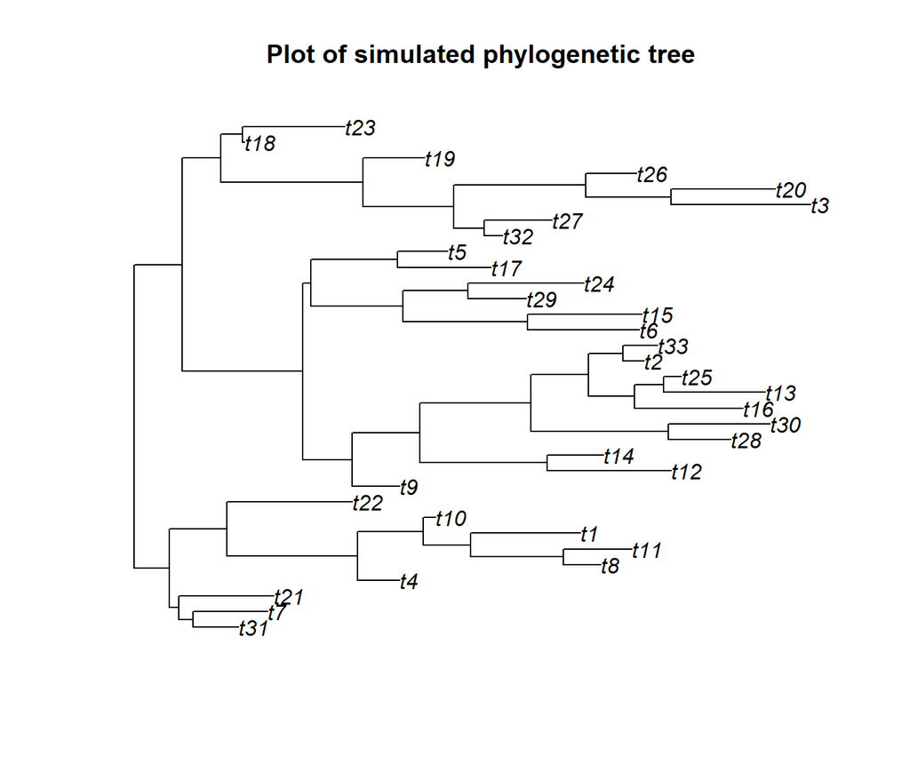

# Assignment 2

## Question 2.1

**1. Some basic statistics on each sequence dataset:**

As you can be see below, base composition, G+C content and A+T content are very similar but not exactly the same across data sets (because of the random samples).

Base composition

|  | Original | Simulated_Sample | Simulated_Tree |
| --- | --- | --- | --- |
| a | 0.3121454 | 0.3120196 | 0.3150152 |
| c | 0.2052325 | 0.2045236 | 0.2061061 |
| g | 0.2307222 | 0.2329182 | 0.2258333 |
| t | 0.2518999 | 0.2505387 | 0.2530455 |

Percentage of G + C

| Original | Simulated_Sample | Simulated_Tree |
| --- | --- | --- |
| 0.4359547 | 0.4374417 | 0.4319394 |

Percentage of A + T

| Original | Simulated_Sample | Simulated_Tree |
| --- | --- | --- |
| 0.5640453 | 0.5625583 | 0.5680606 |

**2. Translate nucleotide sequences into protein sequences & report amino acid composition:**

The overview of the amino-acid composition by data set can be seen in the table “Amino Acid Composition (in %)”.

- *Overall:* Overall, the amino-acid compositions are similar. However, they can differ by up to ca. 3% by amino-acid.
- *Gaps:* Note that gaps (“X”) were recognized for the original data set but not for the sampled data sets. According to the docu of ape::trans, this is because of alignment gaps when e.g. the sequence does not have full 3 proteins.

Amino Acid Composition (in %)

Name

Original

Simulated_Sample

Simulated_Tree

Stp

0.0582622

0.0604643

0.0606516

A

Ala

0.0417469

0.0504175

0.0478205

C

Cys

0.0435361

0.0290852

0.0254800

D

Asp

0.0367924

0.0311038

0.0323505

E

Glu

0.0603725

0.0401872

0.0384020

F

Phe

0.0378475

0.0298651

0.0292565

G

Gly

0.0501881

0.0545922

0.0475475

H

His

0.0348656

0.0304615

0.0307125

I

Ile

0.0369759

0.0601431

0.0593776

K

Lys

0.0674833

0.0528030

0.0551006

L

Leu

0.0864758

0.0829893

0.0887251

M

Met

0.0182586

0.0181668

0.0188825

N

Asn

0.0338563

0.0453253

0.0465465

P

Pro

0.0578952

0.0410588

0.0439985

Q

Gln

0.0461510

0.0358749

0.0334880

R

Arg

0.0637673

0.0853748

0.0882246

S

Ser

0.0901918

0.0821635

0.0849486

T

Thr

0.0501422

0.0634921

0.0628811

V

Val

0.0434902

0.0578035

0.0549186

W

Trp

0.0186256

0.0139462

0.0124670

Y

Tyr

0.0221580

0.0346821

0.0382200

X

gaps

0.0009175

0.0000000

0.0000000

**3. Obtain number of stop codons in simulated sequences & compare to true seq:**

The number of stop codons can be seen in the table “Number of Stop Codons”. There are 1270 stop codons in the original sequence, 1318 stop codons in the simulated sequence without and 1333 stop codons in the simulated sequence with trees.

Number of Stop Codons

Original

1270

Simulated_Sample

1318

Simulated_Tree

1333

## Question 2.2

**Expected Markov chain order:**

For the simulated data sets, we would expect order of 1 because here, the nucleotides are indeed random and should therefore be independent.

We would expect order of 2 (or more) for the original data sets because three nucleotides code for an amino-acid and since the amino-acids are not fully independent in the DNA. Note that the number of required free parameters increases a lot from 2 to 3 (see below). The larger the number of parameters, the less reliable the estimated probabilities for the transition matrix will be. The number of nucleotides for the data sets are: 65435 for original data set and sampled data set and 66000 for the data set sampled from the trees. If you consider the number of parameters for the 1st to 3rd order below, it should be realistic to estimate parameters for at least 2nd order given the amount of data available.

Number of free parameters required for order of 1:
$$4 * (4-1) = 12$$
Number of free parameters required for order of 2:
$$4^2 * (4^2-1) = 240$$

Number of free parameters required for order of 3:
$$4^3 * (4^3-1) = 4032$$

**Assess Markov chain order:**

First, we concatenate the sequences from the three data sets and remove any characters that are not “a”, “c”, “g”, “t”. Then, we conduct a Chi-Square test with the H0: Sequence is of 1st order. The H0 gets rejected for the original sequence (since p = 0) but not for the two sampled sequences (as p > 0.05). This is what we expected: First order Markov chains for the randomly sampled sequence but second or higher order Markov chains for the original sequence (in which dependency exists).

```
## Assess the order with Chi-Square test:
```

```
## Original: p =  0
```

```
##
## Simulated_Sample: p = 0.9276794
```

```
##
## Simulated_Tree: p = 0.9823262
```

**Fit Markov chains:**

Lastly, we fit 1st order Markov chains for all three data sets. The corresponding three transition matrices can be found below.

Note that we tried to fit a higher order Markov chain for the original data set (since this would be appropriate based on the Chi-Square-Test). However, the function fitHigherOrder from the markovchain package did not produce correct transition matrices and we also did not find any other package that could fit a higher order Markov chain correctly. Therefore, we also fit a 1st order Markov chain for the original data set.

```
## Original
##  A  4 - dimensional discrete Markov Chain defined by the following states:
##  a, c, g, t
##  The transition matrix  (by rows)  is defined as follows:
##           a         c          g         t
## a 0.3378239 0.1733209 0.27506981 0.2137853
## c 0.3793026 0.2478021 0.05029057 0.3226047
## g 0.3937305 0.2032607 0.19338591 0.2096229
## t 0.1509045 0.2119097 0.35698677 0.2801991
```

```
## Simulated_Sample
##  A  4 - dimensional discrete Markov Chain defined by the following states:
##  a, c, g, t
##  The transition matrix  (by rows)  is defined as follows:
##           a         c         g         t
## a 0.3122551 0.2044475 0.2327586 0.2505388
## c 0.3213779 0.2014496 0.2317866 0.2453859
## g 0.3081163 0.2106817 0.2312840 0.2499180
## t 0.3076735 0.2014152 0.2355740 0.2553373
```

```
## Simulated_Tree
##  A  4 - dimensional discrete Markov Chain defined by the following states:
##  a, c, g, t
##  The transition matrix  (by rows)  is defined as follows:
##           a         c         g         t
## a 0.3145262 0.2061087 0.2279942 0.2513709
## c 0.3175035 0.2039991 0.2243623 0.2541351
## g 0.3174103 0.2093257 0.2207313 0.2525327
## t 0.3114784 0.2049578 0.2289084 0.2546554
```

Now, we consider the assumptions behind the analyses (see book “Statistical Methods in Bioinformatics”):

1. *Markov property*: “current state is all that matters in determining the probabilities for the states that the process will occupy in the future.
2. *Temporally homogeneous transition probabilities property*: given that at time t, the process is in state $E_{j}$, the probability that one time unit later it is in state $E_{k}$ is independent of t.

We consider nucleotide sequences here.

1. The *Markov property* may be violated, especially in the original sequence because the nucleotides code for amino-acids that will later on be translated into proteins. Therefore, one cannot actually assume that the previous nucleotides don’t matter in determining the probabilities for the next states.
2. Regarding the second property, we don’t consider time here but space (i.e. position of the nucleotides). It is a valid assumption that the position does not matter (however the type of the previous nucleotides does, see 1.).

## Question 2.3

- **Choose a distance measure between sequences.**
- **Calculate for each alignment the distances between all pairs of sequences.**
- **Plot heatmaps visualizing the distances.**
- **Comment on what you can observe.**

Clustal Omega (https://www.ebi.ac.uk/Tools/msa/clustalo/) was used for performing the multiple sequence alignment. An alternative would be using the package `DECIPHER` with the function `AlignSeqs`. On the webpage the following three steps were done for each of the sequences in the `data` folder.

1. DNA was selected as the set and the `.fasta`file was uploaded via the `Browse` button.
2. The output format was changed to `Pearson/FASTA`.
3. The job was submitted.

The job will run for a few seconds or minutes. After that the button “Download Alignment File” can be used to inspect the generated `.fasta` file containing the aligned sequences. We saved the file in the `data` folder.

We used the function `dist.alignment` from the `seqinr` package for calculating the distances. The documentation states:

> These functions compute a matrix of pairwise distances from aligned sequencesusing similarity (Fitch matrix, for protein sequences only) or identity matrix (for protein and DNA sequences).

After the function call we get a identity matrix. The definition of the identity as a distance measure is that both sequences which are to be compared are aligned in any way (Clustal Omega here), Then we count the number of nucleotides which are identical and divide it by the length of the sequences. We get a percentage score which is the value in the matrix. We went for this as the sequence distance at it is most often used for that purpose (http://tbb.bio.uu.nl/BDA/2017/20170221_quantifying_sequence_similarity.pdf slide 4).

Here are the generated Heatmaps visualizing the distance matrices:

Heatmap for the original sequences.

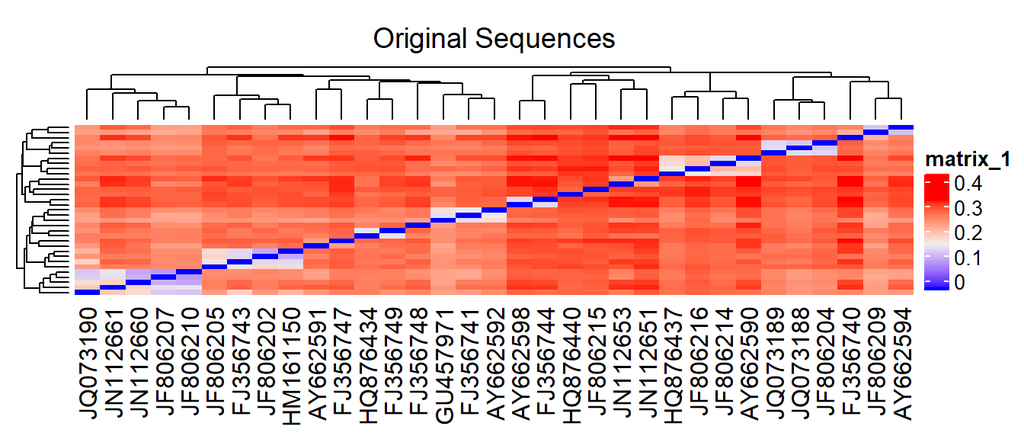

Heatmap for the simulated sequences.

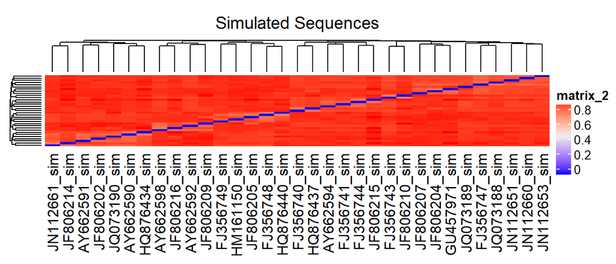

Heatmap for the simulated sequences (tree).

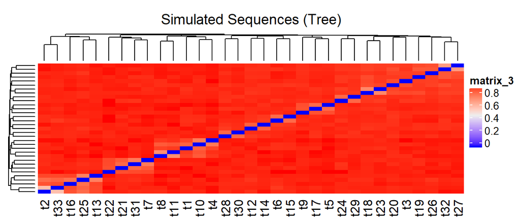

We assume the reason for this is that the original data is indeed not independent, which is the same conclusion we could observe trying fitting the markov chains. The simulated data is independent, therefore we cannot observe that many similarities. The only thing which sticks out is, that on the diagonal, we can observe some sequences which seem to be related.

# Question 3

## Question 3.1

**Construct phylogenetic trees from the three multiple alignments (or distance matrices)**

### UPGMA tree of the original data

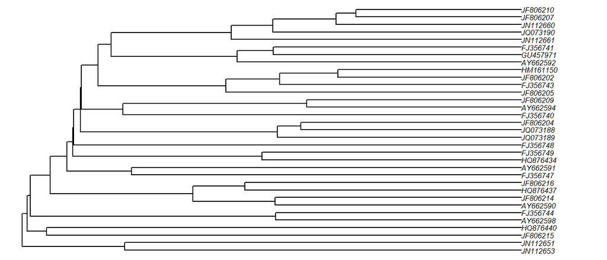

### UPGMA tree of the simulated data

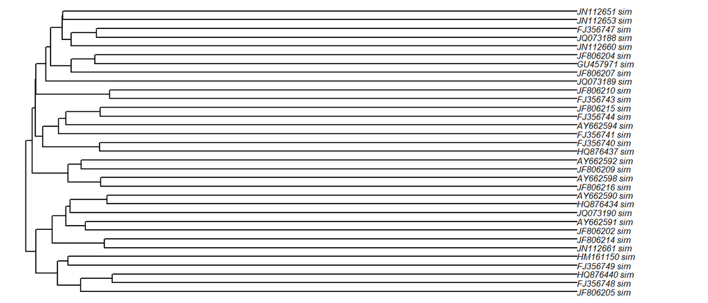

### UPGMA tree of the simulated data (tree)

Estimated tree from simulated data according to the tree structure.

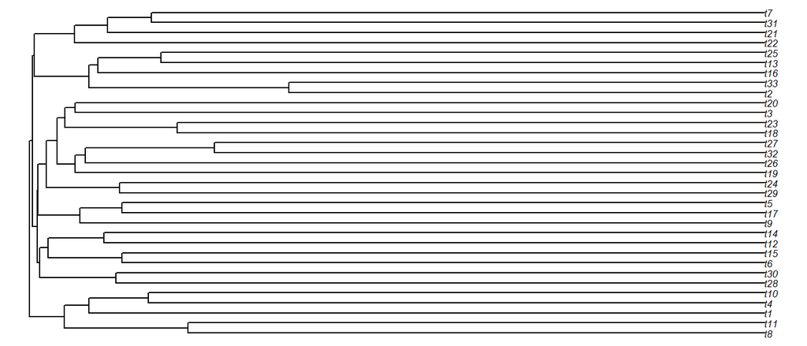

Are the two based on the simulated data similar to expected? :Compare to the tree from original data, tree from two simulated data is more balanced. From the tree based on original data, we can see that lizards are phylogenetically related so we can group them into few family group. However, tree from two simulated data are more randomly distributed, less lizards are phylogenetically related.

**Perform a phylogenetic bootstrap analysis**

### Bootstrap of original sequences

UPGMA tree of the original data with the bootstrap support for the individual clades.

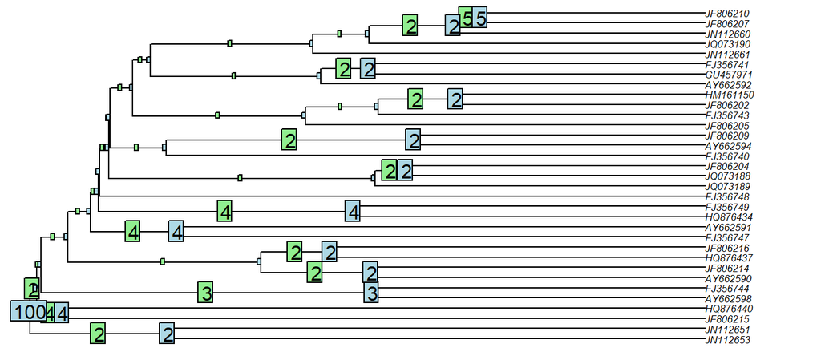

### Bootstrap of simulated sequences

UPGMA tree of the simulated data with the bootstrap support for the individual clades.

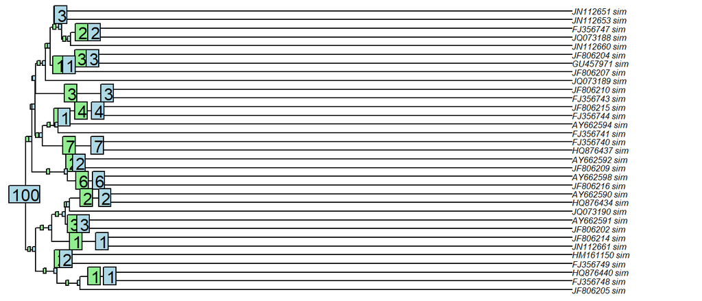

### Bootstrap of simulated sequences from tree

UPGMA tree of the simulated data (from tree) with the bootstrap support for the individual clades.

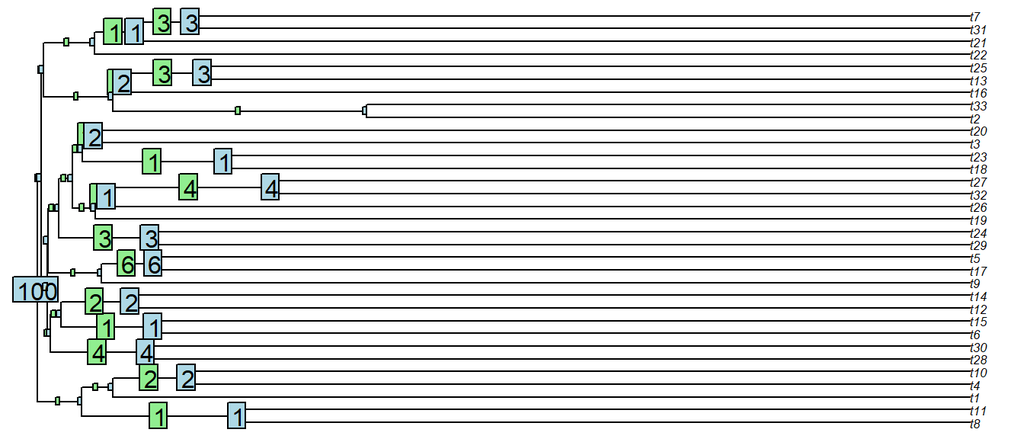

## Question 3.2 Compare your inferred trees and also your simulated one

**by comparing indices** tci() function from TotalCopheneticIndex package - it calculates the total cophenetic index for any tree, which is a measure of tree balance.

Total cophenetic index for tree

| original_tree | 466 |
| --- | --- |
| simulated_sample | 276 |
| simulated_tree | 388 |

For every pair of leaves $i,j$ in a phylogenetic tree $T$, their cophenetic value is the depth of their lowest common ancestor. The total cophenetic index of a phylogenetic tree is the sum of the cophenetic values of its pairs of different leaves(Mir, Rosselló, and Rotger 2013). The tree with the smallest total cophenetic value is the maximally balanced while the tree with the largest total cophenetic value is the caterpillar shaped tree. From the table above, we can conclude that given three trees are not in balanced shape.

- treedist() function from phangorn package

  |  | Ori_vs_Sample | Ori_vs_Tree | Sample_vs_Tree |
  | --- | --- | --- | --- |
  | symmetric.difference | 42.000000 | 54.000000 | 46.0000000 |
  | branch.score.difference | 1.706335 | 1.626603 | 0.2917597 |
  | path.difference | 86.069739 | 86.243840 | 54.7539953 |
  | quadratic.path.difference | 13.143949 | 13.129707 | 0.5133044 |

  Treedist() returns a vector containing the following tree distance methods: symmetric difference, branch score difference, path difference and quadratic path difference. The larger the value is, the more different the trees are. From the table below, we can figure out that in overall, the tree from simulated alignment and the tree with the alignment from simulated tree are the most similar among the given trees.
- cor_cophenetic() function from dendextend package

  | Original_vs_simulatedSample | Original_vs_simulatedTree | simualtedSample_vs_simulatedTree |
  | --- | --- | --- |
  | -0.0076625 | -0.0299418 | -0.0623265 |

# Appendix

```r
## TODO
# - heatmaps: Name and describe the clusters (adjacency representation)
# - 3.1 Specifially answer "Are the two based on the simulated data similar to expected?"(done)
# - 3.2 check for grammar mistakes
# - "phylogenetic bootstrap analysis", not just plotting, also describing
# - save the trees as a file and read them
# - 3.2 Interpet table (i think it's done)
# - 3.2 Fix bug: simulated_sample = index_original is wrong (done)


knitr::opts_chunk$set(fig.width = 7, fig.height = 3, echo = FALSE,
                      warning = FALSE, message = FALSE)

library(dplyr)
library(tidyr)
library(magrittr)
library(ape)          # This is a general R-package for phylogenetics
                      # and comparative methods
library(seqinr)       # This is an specialized package for
                      # nucleotide sequence management
library(phangorn)
library(knitr)
library(markovchain)  # For fitting, evaluating Markov chains (question 2)

# Use this if BiocManager is not installed
#if (!requireNamespace("BiocManager", quietly = TRUE))
#    install.packages("BiocManager")
#library("BiocManager")

# BiocManager packages
#BiocManager::install("ComplexHeatmap", version = "3.8")

library(ComplexHeatmap)
library(circlize)

library(TotalCopheneticIndex) #for getting tree index
library(dendextend) #for getting correlation distance

source("732A51_BioinformaticsHT2018_Lab02_GenBankGetCode.R")

# ------------------------------------------------------------------------------
# Question 1.1
# ------------------------------------------------------------------------------

lizards_format_sequences = read.fasta(file = "data/lizard_seqs.fasta")
# Alternative version of the file. Useful in some ways?

n = length(lizards_accession_numbers)  # Number of sequences to reproduce
p = base.freq(lizards_sequences)  # Probability of the base sequences
simulated_lizards = list()  # Object that will contain our simulated data

# The names of the simulated data are the original names + "_sim"
# NOTE: it does not follow the format from GenBank
simulated_names = paste(lizards_accession_numbers, "_sim", sep = "")

set.seed(1535)  # Set seed in order to reproduce the experiment
for(i in 1:n) {  # Cycle through every single object of the lizard_sequences
  len_seq = length(lizards_sequences[[i]])  # Lenght of each sequence
  simulated_lizards[[ simulated_names[i] ]] =
    sample(c("a", "c", "g", "t"), len_seq, replace = T, prob = p)
  # Creating the artificial sequence sampling with probabilities p
  # that are equal to the original ones.
  # NOTE: we use the general distribution for every single sequence
}

# Save as fasta file
write.dna(simulated_lizards, file = "data/simulated_lizards.fasta",
          format = "fasta", append = F, nbcol = 6, colsep = " ", colw = 10)

# Table with simulated base frequency
df_table = data.frame("Base" = c("a", "c", "g", "t"),
                       "Original\nfrequency" = p,
                       "Simulated\nfrequency" =
                        base.freq(as.DNAbin(simulated_lizards)),
                       row.names = NULL)
# base.freq computes the frequencies of the four DNA bases from a sample of
# sequences.

kableExtra::kable(df_table, booktabs = T, align = c("r", "l", "l"),
      col.names = c("Base", "Original\nfrequency", "Simulated\nfrequency"),
      format = "latex", caption = "Base frequencies of the 33 original and
      generated DNA sequences.", digits = c(NA, 4, 4)) %>%
  kableExtra::kable_styling(latex_options = "hold_position")


# ------------------------------------------------------------------------------
# Question 1.2
# ------------------------------------------------------------------------------

# Simulate phylogenetic tree with 33 tips in phylo format (ape) ----------------
set.seed(1)
tree = ape::rtree(n = 33)

# Simulate sequences on this tree using phangorn::simSeq() ---------------------
Q = matrix(c(.1, .8, .05, .05,
             .35, .1, .1, .45,
             .3, .2, .2, .3,
             .6, .1, .25, .05), nrow = 4, byrow = TRUE)
rownames(Q) = c("a", "c", "g", "t")
colnames(Q) = c("a", "c", "g", "t")

Original = p

tree_sequences_sim = phangorn::simSeq(tree, l = 2000, Q = Q, bf = Original)

# Explanation of parameters:
# l = 2000 because average sequence length in given data is ca. 2000
# bf = Original because this is the vector with the original base proportions
# Q = just chosen the matrix from Special Exercise 1 (Question 3)

# Convert to DNAbin
tree_sequences_sim = as.DNAbin(tree_sequences_sim)

# Save simulated sequences as fasta file ---------------------------------------

# Write simulated lizard sequences as fasta file
ape::write.dna(tree_sequences_sim, file ="data/simulated_lizards_tree.fasta",
               format = "fasta", append = F, nbcol = 6, colsep = " ", colw = 10)

stationary = Q%*%Q%*%Q%*%Q%*%Q%*%Q%*%Q%*%Q%*%Q%*%Q%*%Q%*%Q%*%Q%*%Q%*%Q%*%Q%*%Q

# Report base composition ------------------------------------------------------

# Table with simulated base frequency
df_table = data.frame("Base" = c("a", "c", "g", "t"),
                      "Original\nfrequency" = Original,
                      "Simulated\nfrequency" = base.freq(tree_sequences_sim),
                      "Stationary\ndistribution" = stationary[1,],
                      row.names = NULL)

kableExtra::kable(df_table, booktabs = T, align = c("r", "l", "l", "l"),
      digits = c(NA, 4, 4, 4),
      col.names = c("Base", "Original\nfrequency", "Simulated\nfrequency",
                    "Stationary\ndistribution"),
      format = "latex", caption = "Base frequencies of the 33 original DNA
      sequences and of the 33 simulated phylogenetic trees.") %>%
  kableExtra::kable_styling(latex_options = "hold_position")

# Plot the tree ----------------------------------------------------------

plot(tree, edge.width = 1, main = "Plot of simulated phylogenetic tree")
# phytools::plotTree(tree) # Alternative

# ------------------------------------------------------------------------------
# Question 2.1
# ------------------------------------------------------------------------------
```

```r
# First read in all the data again
original = ape::read.FASTA(file = "data/lizard_seqs.fasta", type = "DNA")
sim_sample = ape::read.FASTA(file = "data/simulated_lizards.fasta", type = "DNA")
sim_tree = ape::read.FASTA(file = "data/simulated_lizards_tree.fasta", type = "DNA")

# 1. Some basic statistics on each sequence dataset ----------------------------

# Individual base composition
kableExtra::kable(data.frame(Original = ape::base.freq(original),
             Simulated_Sample = ape::base.freq(sim_sample),
             Simulated_Tree = ape::base.freq(sim_tree)),
             caption = "Base composition", booktabs = T) %>%
  kableExtra::kable_styling(latex_options = "hold_position")

# GC content
kableExtra::kable(data.frame(Original = ape::GC.content(original),
             Simulated_Sample = ape::GC.content(sim_sample),
             Simulated_Tree = ape::GC.content(sim_tree)),
             caption = "Percentage of G + C", booktabs = T) %>%
  kableExtra::kable_styling(latex_options = "hold_position")

# AT content
kableExtra::kable(data.frame(Original = 1 - ape::GC.content(original),
             Simulated_Sample = 1 - ape::GC.content(sim_sample),
             Simulated_Tree = 1 - ape::GC.content(sim_tree)),
             caption = "Percentage of A + T", booktabs = T) %>%
  kableExtra::kable_styling(latex_options = "hold_position")


# 2. Translate nucleotide sequences into protein sequences & report amino acid comp.

# Create function to obtain amino acid percentages from DNAbin
get_aa_comp = function(DNAbin, relative = TRUE){

  # Data conversion to obtain amino distribution

  original_amino = ape::trans(DNAbin) # Convert DNAbin to AAbin (amino acids)
  original_amino = as.character(original_amino) # convert AAbin to char list
  original_amino = unlist(original_amino) # convert char list to char vector

  # Report amino acid composition

  if (relative == TRUE) {
    # Compute percentages (default)
    metric = as.numeric(table(original_amino)) / length(original_amino)
    names(metric) = names(table(original_amino))
  } else {
    # Compute counts
    metric = as.numeric(table(original_amino))
    names(metric) = names(table(original_amino))
  }

  return(metric)
}

# Obtain percentages by amino acid precentages
Simulated_Sample = get_aa_comp(sim_sample)
Simulated_Tree = get_aa_comp(sim_tree)
Original = get_aa_comp(original)

# Original has an X at second to last position, we need to account for that
# According to docu of ape::trans, this is because of alignment gaps when
# e.g. the sequence does not have full 3 proteins.
Simulated_Sample = c(Simulated_Sample, X = 0) # Add X = 0 to simulated sample
Simulated_Tree = c(Simulated_Tree, X = 0)     # Add X = 0 to simulated sample
Original = Original[c(1:(length(Original)-2), # Let X be last value in original
                      length(Original), length(Original)-1)]

kableExtra::kable(data.frame(Name = c(seqinr::aaa(), "gaps"),
                        Original,
                        Simulated_Sample,
                        Simulated_Tree),
             caption = "Amino Acid Composition (in \\%)", booktabs = T) %>%
  kableExtra::kable_styling(latex_options = "hold_position")


# 3. Obtain number of stop codons in simulated sequences & compare to true seq

Simulated_Sample = get_aa_comp(sim_sample, relative = FALSE)
Simulated_Tree = get_aa_comp(sim_tree, relative = FALSE)
Original = get_aa_comp(original, relative = FALSE)

kableExtra::kable(t(data.frame(Original = Original["*"],
               Simulated_Sample = Simulated_Sample["*"],
               Simulated_Tree = Simulated_Tree["*"])),
             caption = "Number of Stop Codons", booktabs = T) %>%
  kableExtra::kable_styling(latex_options = "hold_position")


# ------------------------------------------------------------------------------
# Question 2.2
# ------------------------------------------------------------------------------

# 1. Concatenate the sequences from the three data sets and remove any
# characters that are not "a", "c", "g", "t"

original_seq = unlist(as.character(original)) # obtain character vector
original_seq = original_seq[original_seq %in% c("a", "c", "g", "t")] # a, c, g, t

sim_sample_seq = unlist(as.character(sim_sample)) # obtain character vector
sim_sample_seq = sim_sample_seq[sim_sample_seq %in% c("a", "c", "g", "t")] # a, c, g, t

sim_tree_seq = unlist(as.character(sim_tree)) # obtain character vector
sim_tree_seq = sim_tree_seq[sim_tree_seq %in% c("a", "c", "g", "t")] # a, c, g, t

# 2. Assess the order with Chi-Square test

# This test returns a list of the chi-squared value and the p-value.
# If the p-value is greater than the given significance level, we cannot reject
# the hypothesis that the sequence is of first order.

cat("Assess the order with Chi-Square test:\n")

cat("Original: p = ",
assessOrder(original_seq, verbose = FALSE)$p.value)

cat("\nSimulated_Sample: p =",
assessOrder(sim_sample_seq, verbose = FALSE)$p.value)

cat("\nSimulated_Tree: p =",
assessOrder(sim_tree_seq, verbose = FALSE)$p.value)

# 3. Fit markov chains

# 1st order markov chains for sampled data --------------------------------------

original_fit = markovchainFit(data = original_seq, confidencelevel = 0.95,
                              name = "Original")
original_fit$estimate; cat("\n-------------\n")

sim_sample_fit = markovchainFit(data = sim_sample_seq, confidencelevel = 0.95,
                              name = "Simulated_Sample")
sim_sample_fit$estimate; cat("\n-------------\n")


sim_tree_fit = markovchainFit(data = sim_tree_seq, confidencelevel = 0.95,
                              name = "Simulated_Tree")
sim_tree_fit$estimate


# Fitting higher order markov chains did not work
# original_fit_2nd = fitHigherOrder(original_seq, order = 2)
# cat("Original, 2nd order:\n\n"); original_fit_2nd; cat("\n-------------\n")

# ------------------------------------------------------------------------------
# Question 2.3
# ------------------------------------------------------------------------------
# It'd be nice to do the multiple sequence alignment in R code, but due to the
# fact that for the moment it's not working and that it takes a long compilation
# time (>1 minute) we will use Clustal Omega for now:
# (https://www.ebi.ac.uk/Tools/msa/clustalo/)
# In the stack overflow thread Krzysztof suggested the package 'DECIPHER' is
# also recommended.: (http://www2.decipher.codes/Alignment.html)
# The progress of the testing of the multiple sequence alignment in R can be
# found in multi_sequence_alignment.R
# For the heatmapes ths may be used: https://davetang.org/muse/2018/05/15/making-a-heatmap-in-r-with-the-pheatmap-package/
```

```r
# Read the DNA alignments
original_as_alignment =
  read.alignment("data/aligned_clustalo_lizard_seqs.fasta",
                 format = "fasta")
sim_sample_as_alignment =
  read.alignment("data/aligned_clustalo_simulated_lizards.fasta",
                 format = "fasta")
sim_tree_as_alignment =
  read.alignment("data/aligned_clustalo_simulated_lizards_tree.fasta",
                 format = "fasta")

# Get the distances (useful in 3.1). The distance function is "unclear", the
# documentation says "specified distance measure". We can also use a different
# one.
dist_original =
  dist.alignment(original_as_alignment, matrix = "identity")
dist_sim_sample =
  dist.alignment(sim_sample_as_alignment, matrix = "identity")
dist_sim_tree =
  dist.alignment(sim_tree_as_alignment, matrix = "identity")

# Get the distance matrixes (for heatmaps)
dist_mat_original = Biostrings::as.matrix(dist_original)
dist_mat_sim_sample = Biostrings::as.matrix(dist_sim_sample)
dist_mat_sim_tree =Biostrings::as.matrix(dist_sim_tree)


# Heatmap examples cen be found here:
# https://bioconductor.org/packages/release/bioc/vignettes/ComplexHeatmap/inst/doc/s2.single_heatmap.html
# If you don't like Heatmeap, we can also use someting else
Heatmap(dist_mat_original, column_title = "Original Sequences",
        show_row_names = FALSE)


Heatmap(dist_mat_sim_sample, column_title = "Simulated Sequences",
        show_row_names = FALSE)


Heatmap(dist_mat_sim_tree, column_title = "Simulated Sequences (Tree)",
        show_row_names = FALSE)

# ------------------------------------------------------------------------------
# Question 3.1
# ------------------------------------------------------------------------------

# Answers based on phagron package vignette
# https://cran.r-project.org/web/packages/phangorn/vignettes/Trees.pdf
# Rooted trees

tree_upgma_original = upgma(dist_original)
tree_upgma_sim_sample = upgma(dist_sim_sample)
tree_upgma_sim_tree = upgma(dist_sim_tree)


plot(tree_upgma_original, type = "phylogram",
     main="", cex = 0.5, no.margin = T)

plot(tree_upgma_sim_sample, type = "phylogram", cex = 0.5, no.margin = T,
     main="")


plot(tree_upgma_sim_tree, type = "phylogram", cex = 0.5, no.margin = T,
     main="")


# Bootstrapping
# Followed the examples in ?boot.phylo
boot_original = ape::boot.phylo(nj(dist_mat_original), dist_mat_original,
                                nj, trees = T)$trees
clad_original = prop.clades(tree_upgma_original, boot_original, rooted = TRUE)
boot = prop.clades(tree_upgma_original, boot_original)


plot(tree_upgma_original, type = "phylogram",
     main="", cex = 0.5, no.margin = T)
drawSupportOnEdges(boot)
nodelabels(clad_original)


# Bootstrapping
# Followed the examples in ?boot.phylo
boot_sim_sample = ape::boot.phylo(nj(dist_mat_sim_sample), dist_mat_sim_sample,
                                nj, trees = T)$trees
clad_sim_sample = prop.clades(tree_upgma_sim_sample, boot_sim_sample, rooted = T)
boot = prop.clades(tree_upgma_sim_sample, boot_sim_sample)


plot(tree_upgma_sim_sample, type = "phylogram",
     main="", cex = 0.5, no.margin = T)
drawSupportOnEdges(boot)
nodelabels(clad_sim_sample)


# Bootstrapping
# Followed the examples in ?boot.phylo
boot_sim_tree = ape::boot.phylo(nj(dist_mat_sim_tree), dist_mat_sim_tree,
                                nj, trees = T)$trees
clad_sim_tree = prop.clades(tree_upgma_sim_tree, boot_sim_tree, rooted = T)
boot = prop.clades(tree_upgma_sim_tree, boot_sim_tree)



plot(tree_upgma_sim_tree, type = "phylogram",
     main="", cex = 0.5, no.margin = T)
drawSupportOnEdges(boot)
nodelabels(clad_sim_tree)

index_original = tci(tree_upgma_original)
index_sample = tci(tree_upgma_sim_sample)
index_tree = tci(tree_upgma_sim_tree)

kableExtra::kable(t(data.frame(original_tree = index_original,
                               simulated_sample = index_sample,
                               simulated_tree = index_tree)),
                  caption = "Total cophenetic index for tree",
                  booktabs = T) %>%
        kableExtra::kable_styling(latex_options = "hold_position")


dist1 = treedist(tree_upgma_original,tree_upgma_sim_sample, check.labels = F)
dist2 = treedist(tree_upgma_original,tree_upgma_sim_tree, check.labels = F)
dist3 = treedist(tree_upgma_sim_sample,tree_upgma_sim_tree, check.labels = F)

kableExtra::kable(data.frame(Ori_vs_Sample = dist1,
                               Ori_vs_Tree = dist2,
                               Sample_vs_Tree = dist3),
                  #caption = "Distance between two trees",
                  booktabs = T) %>%
        kableExtra::kable_styling(latex_options = "hold_position")

cor1 = cor_cophenetic(tree_upgma_original,tree_upgma_sim_sample)
cor2 = cor_cophenetic(tree_upgma_original,tree_upgma_sim_tree)
cor3 = cor_cophenetic(tree_upgma_sim_sample,tree_upgma_sim_tree)

kableExtra::kable(data.frame(Original_vs_simulatedSample = cor1,
                               Original_vs_simulatedTree = cor2,
                               simualtedSample_vs_simulatedTree = cor3),
                  #caption = "Cophenetic Correlation between two trees",
                booktabs = T) %>%
        kableExtra::kable_styling(latex_options = "hold_position")
```

# Bibliography

Mir, Arnau, Francesc Rosselló, and Lucı´a Rotger. 2013. “A New Balance Index for Phylogenetic Trees.” *Mathematical Biosciences* 241 (1): 125–36. doi:https://doi.org/10.1016/j.mbs.2012.10.005.